# Medicago experiment

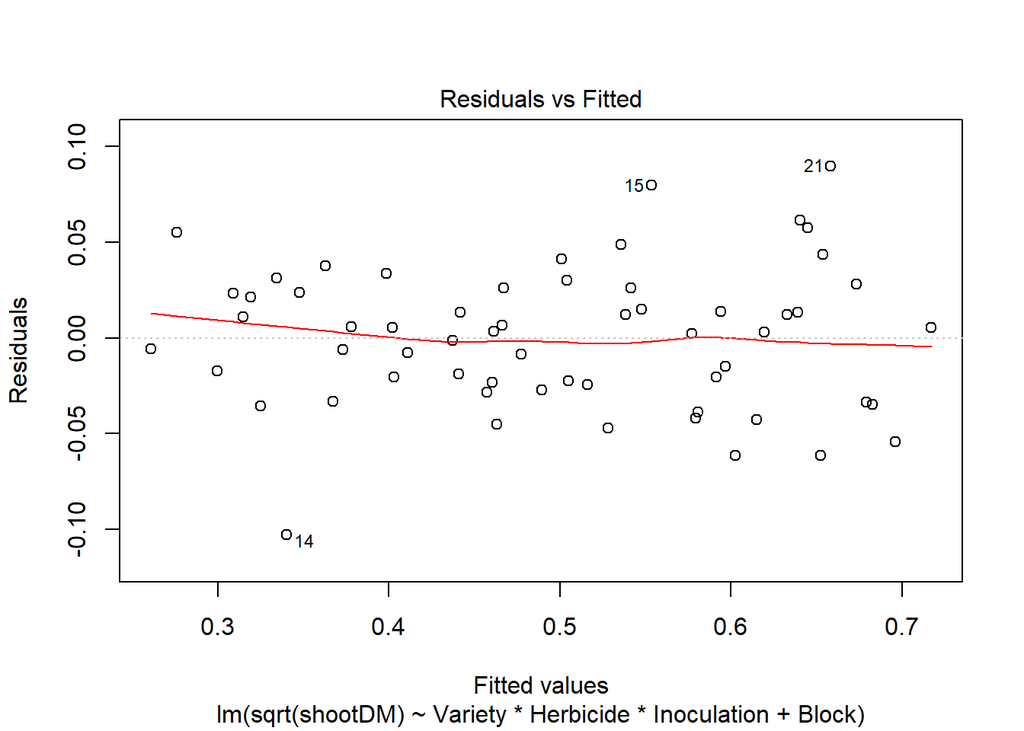

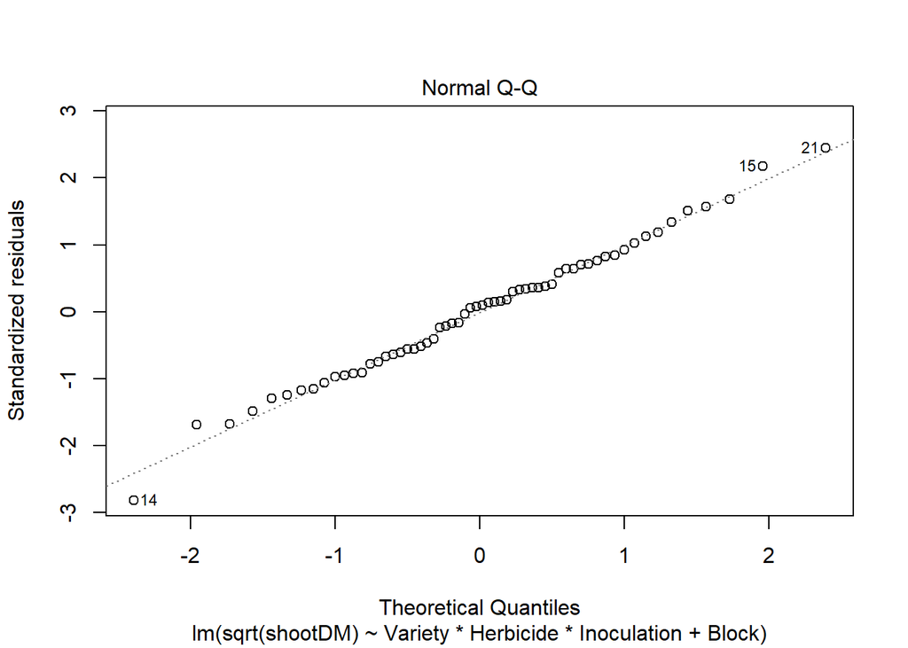

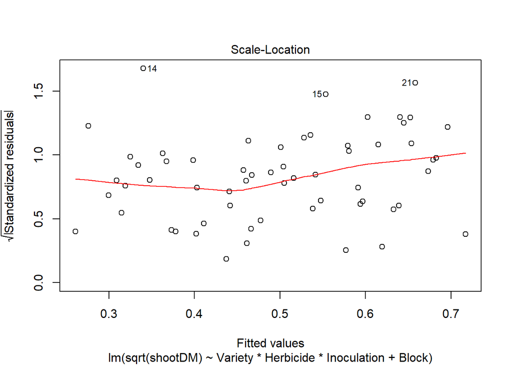

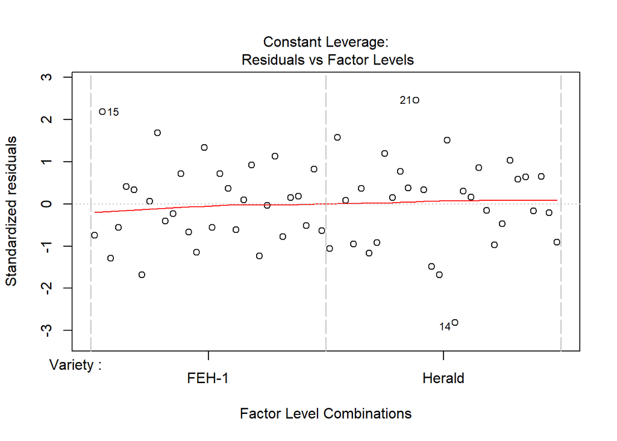

```r
plot(sqrtshootDM_lm)
```

```r
emmeans(sqrtshootDM_lm, ~ Variety*Herbicide, type="response")
```

```
##  Variety Herbicide    response          SE df   lower.CL  upper.CL
##  FEH-1   NoHerbicide 0.3073055 0.012215952 44 0.28317899 0.3324183
##  Herald  NoHerbicide 0.4214274 0.014305515 44 0.39308959 0.4507513
##  FEH-1   Herbicide   0.2060611 0.010003228 44 0.18639402 0.2267144
##  Herald  Herbicide   0.1120509 0.007376492 44 0.09767769 0.1274104
##
## Results are averaged over the levels of: Inoculation, Block
## Confidence level used: 0.95
## Intervals are back-transformed from the sqrt scale
```

```r
emmeans(sqrtshootDM_lm, ~ Herbicide*Inoculation, type="response")
```

```
##  Herbicide   Inoculation  response         SE df  lower.CL  upper.CL
##  NoHerbicide RRI128      0.3452588 0.01585843 44 0.3140379 0.3779590
##  Herbicide   RRI128      0.1539035 0.01058795 44 0.1333045 0.1759818
##  NoHerbicide washed      0.3959530 0.01698281 44 0.3624660 0.4309192
##  Herbicide   washed      0.1462998 0.01032309 44 0.1262346 0.1678442
##  NoHerbicide herb        0.3462775 0.01588181 44 0.3150095 0.3790248
##  Herbicide   herb        0.1666457 0.01101754 44 0.1451809 0.1895897
##
## Results are averaged over the levels of: Variety, Block
## Confidence level used: 0.95
## Intervals are back-transformed from the sqrt scale
```

#### Roots

```r
bgDM_lm <- lm(bgDM ~ Variety*Herbicide*Inoculation + Block, data=inoculated)
anova(bgDM_lm)
```

```
## Analysis of Variance Table
##
## Response: bgDM
##                               Df   Sum Sq  Mean Sq F value    Pr(>F)
## Variety                        1 0.004153 0.004153  6.6586   0.01328 *
## Herbicide                      1 0.037760 0.037760 60.5435 8.340e-10 ***
## Inoculation                    2 0.002210 0.001105  1.7714   0.18201
## Block                          4 0.042624 0.010656 17.0857 1.592e-08 ***
## Variety:Herbicide              1 0.004330 0.004330  6.9427   0.01158 *
## Variety:Inoculation            2 0.000180 0.000090  0.1443   0.86606
## Herbicide:Inoculation          2 0.001912 0.000956  1.5326   0.22727
## Variety:Herbicide:Inoculation  2 0.000223 0.000111  0.1786   0.83703
## Residuals                     44 0.027442 0.000624
## ---
## Signif. codes:  0 '***' 0.001 '**' 0.01 '*' 0.05 '.' 0.1 ' ' 1
```

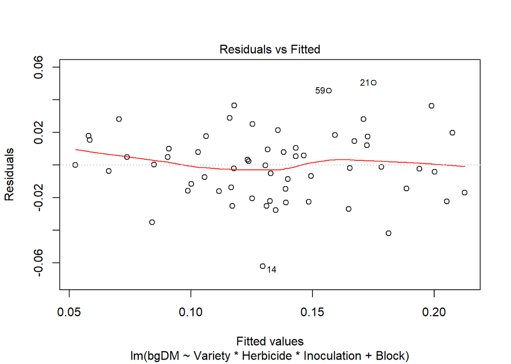

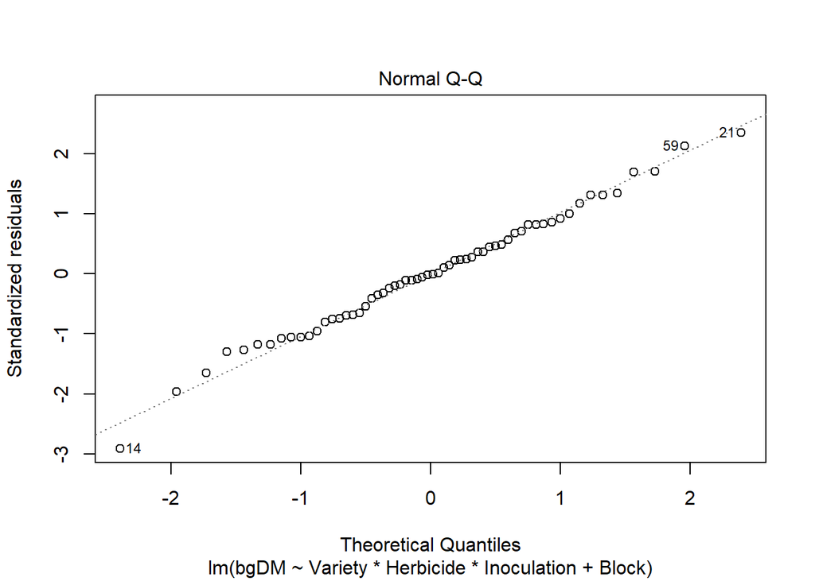

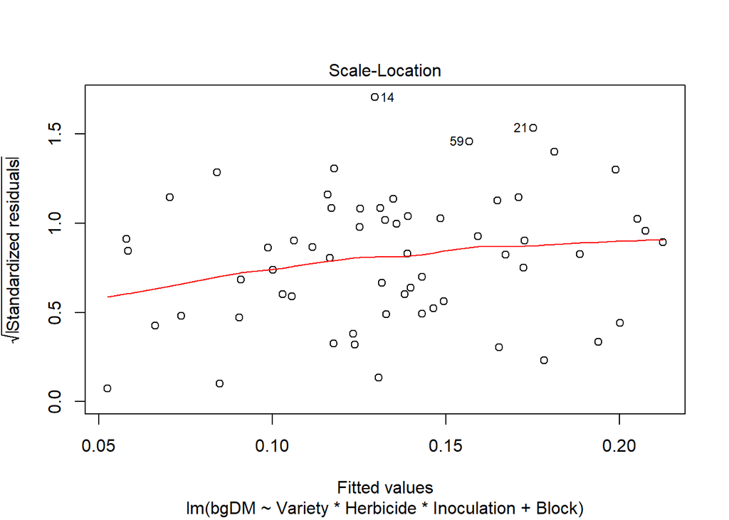

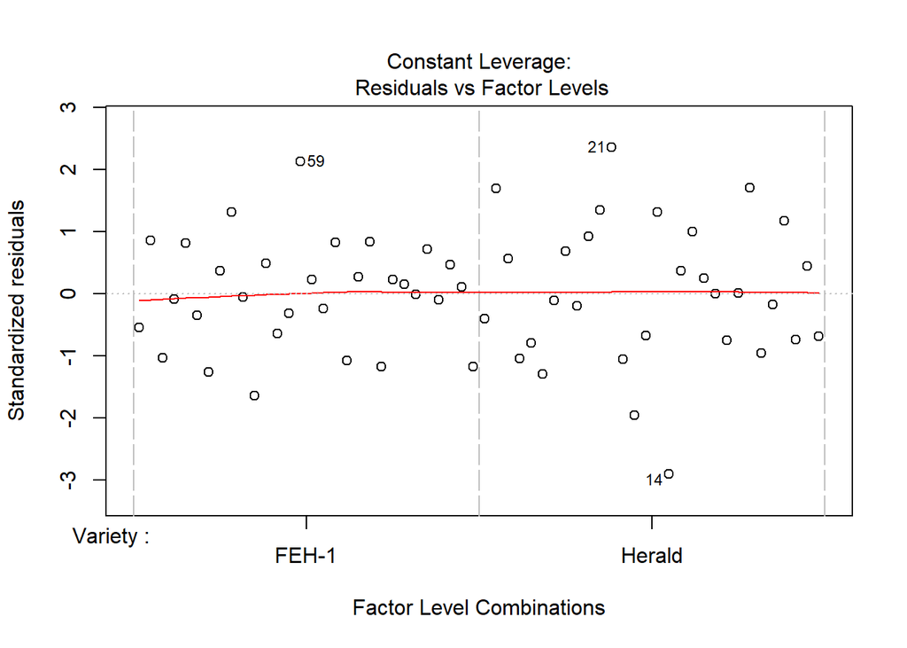

```r
plot(bgDM_lm)
```

```r
emmeans(bgDM_lm, ~ Variety*Herbicide, type="response")
```

```
##  Variety Herbicide      emmean          SE df   lower.CL  upper.CL
##  FEH-1   NoHerbicide 0.1424233 0.006448165 44 0.12942791 0.1554188
##  Herald  NoHerbicide 0.1760527 0.006448165 44 0.16305724 0.1890481
##  FEH-1   Herbicide   0.1092407 0.006448165 44 0.09624524 0.1222361
##  Herald  Herbicide   0.1088893 0.006448165 44 0.09589391 0.1218848
##
## Results are averaged over the levels of: Inoculation, Block
## Confidence level used: 0.95
```

```r
sqrtbgDM_lm <- lm(sqrt(bgDM) ~ Variety*Herbicide*Inoculation + Block, data=inoculated)
anova(sqrtbgDM_lm)
```

```
## Analysis of Variance Table
##
## Response: sqrt(bgDM)
##                               Df   Sum Sq  Mean Sq F value    Pr(>F)
## Variety                        1 0.006532 0.006532  5.5468   0.02304 *
## Herbicide                      1 0.068223 0.068223 57.9306 1.468e-09 ***
## Inoculation                    2 0.004491 0.002245  1.9066   0.16066
## Block                          4 0.088756 0.022189 18.8413 4.341e-09 ***
## Variety:Herbicide              1 0.008619 0.008619  7.3188   0.00967 **
## Variety:Inoculation            2 0.000685 0.000343  0.2909   0.74900
## Herbicide:Inoculation          2 0.004082 0.002041  1.7330   0.18861
## Variety:Herbicide:Inoculation  2 0.000208 0.000104  0.0885   0.91548
## Residuals                     44 0.051818 0.001178
## ---
## Signif. codes:  0 '***' 0.001 '**' 0.01 '*' 0.05 '.' 0.1 ' ' 1
```

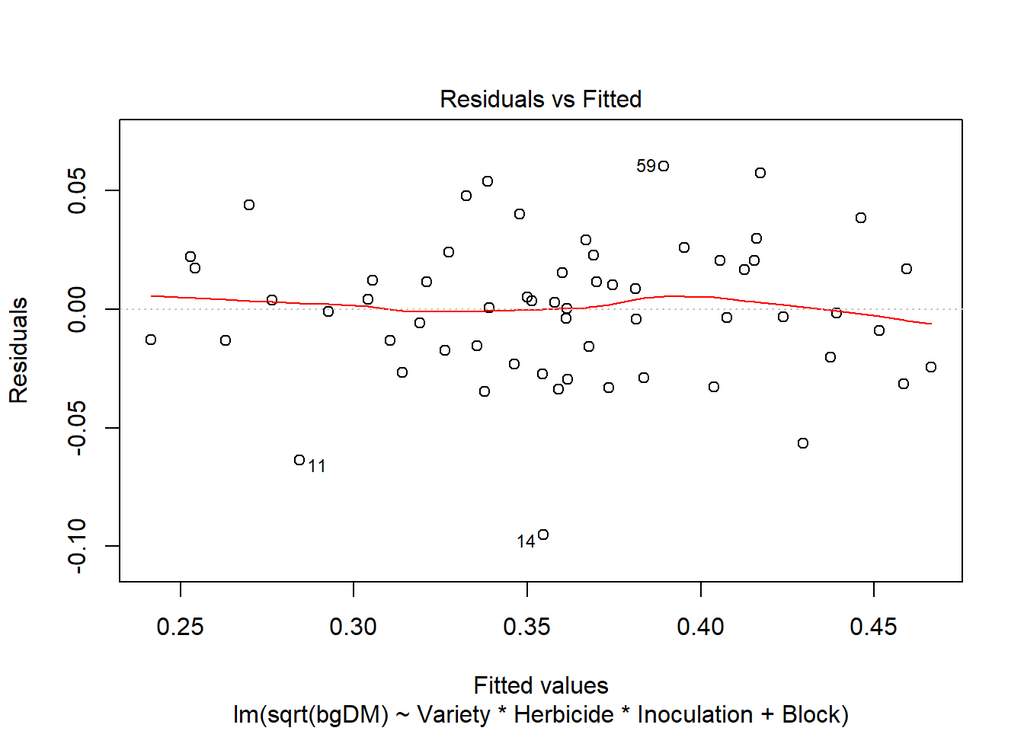

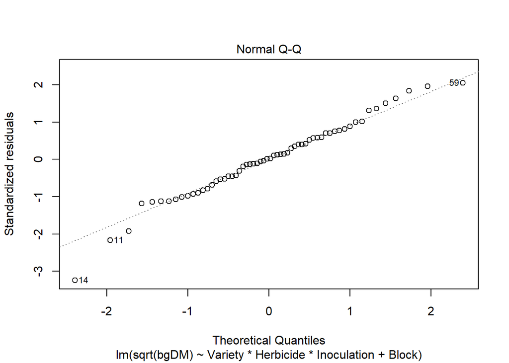

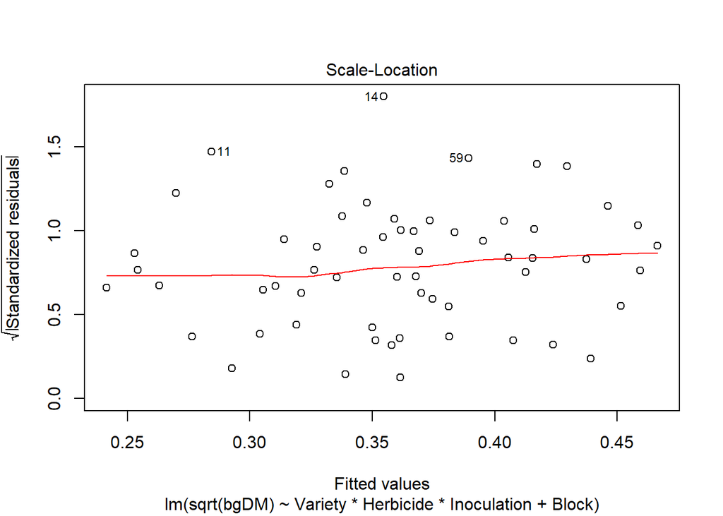

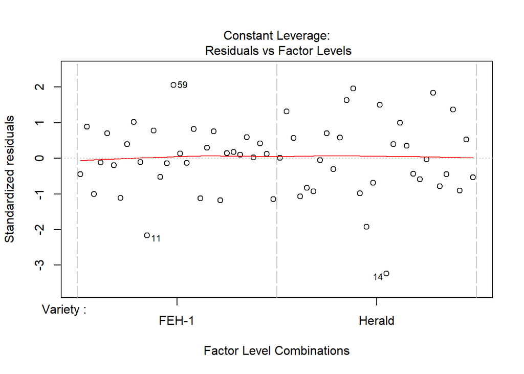

```r
plot(sqrtbgDM_lm)
```

```r
emmeans(sqrtbgDM_lm, ~ Variety*Herbicide, type="response")
```

```
##  Variety Herbicide    response          SE df   lower.CL  upper.CL
##  FEH-1   NoHerbicide 0.1385462 0.006596200 44 0.12557128 0.1521588
##  Herald  NoHerbicide 0.1739366 0.007390811 44 0.15936031 0.1891507
##  FEH-1   Herbicide   0.1080755 0.005825862 44 0.09665313 0.1201356
##  Herald  Herbicide   0.1060451 0.005770878 44 0.09473356 0.1179944
##
## Results are averaged over the levels of: Inoculation, Block
## Confidence level used: 0.95
## Intervals are back-transformed from the sqrt scale
```

### Nodulation

Let’s look at nodules, which are the organs inside which the symbiosis happens. To form nodules, there is some complex signalling between symbionts, infection of roots and development of nodules. Then there is an exchange of compounds. In reality, this experiment is looking at a very specific set of circumstances in which herbicide was applied to the shoots some time after much infection would have occurred. We have nodule numbers which are somewhat arbitrary because clusters of nodules can form, and not all non-pink nodules may have been identified because they may have been too small to notice. We also have nodule masses, which are likely to be more reliable, particularly for pink nodules.

```r
sqrtpinknodmass_lm <- lm(sqrt(pinknodmass) ~ Variety*Herbicide*Inoculation + Block, data=inoculated)
anova(sqrtpinknodmass_lm)
```

```
## Analysis of Variance Table
##
## Response: sqrt(pinknodmass)
##                               Df   Sum Sq  Mean Sq  F value    Pr(>F)
## Variety                        1 0.001310 0.001310   5.1857 0.0276898 *
## Herbicide                      1 0.078098 0.078098 309.2548 < 2.2e-16 ***
## Inoculation                    2 0.000455 0.000228   0.9009 0.4135760
## Block                          4 0.005681 0.001420   5.6244 0.0009566 ***
## Variety:Herbicide              1 0.012006 0.012006  47.5402  1.63e-08 ***
## Variety:Inoculation            2 0.001551 0.000775   3.0706 0.0564525 .
## Herbicide:Inoculation          2 0.001406 0.000703   2.7846 0.0726572 .
## Variety:Herbicide:Inoculation  2 0.000027 0.000014   0.0543 0.9472197
## Residuals                     44 0.011112 0.000253
## ---
## Signif. codes:  0 '***' 0.001 '**' 0.01 '*' 0.05 '.' 0.1 ' ' 1
```

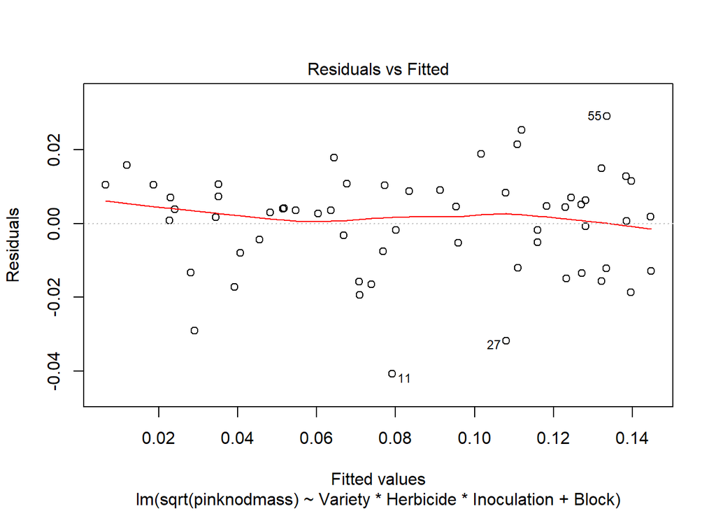

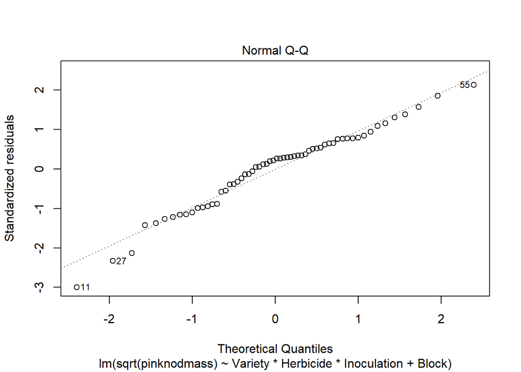

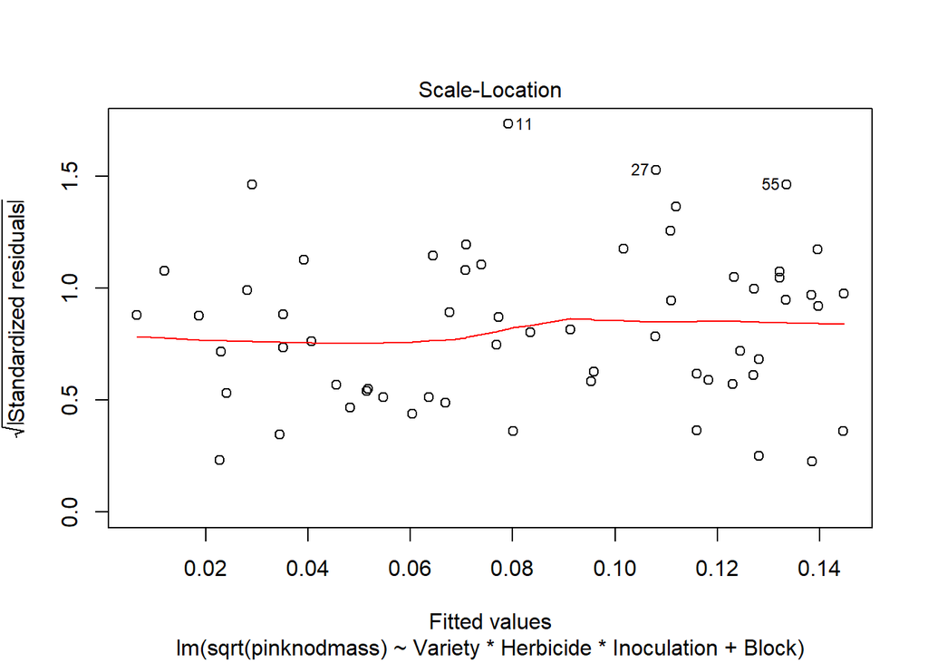

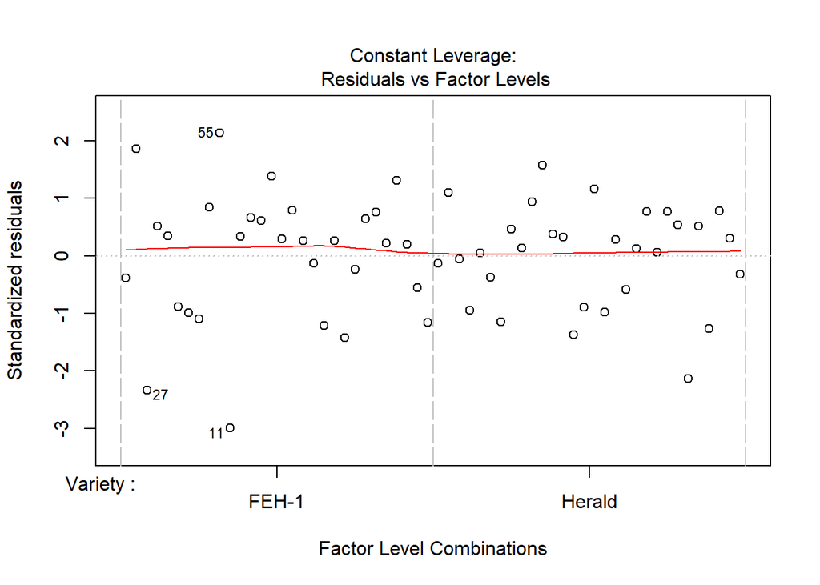

```r
plot(sqrtpinknodmass_lm)
```

```r
emmeans(sqrtpinknodmass_lm, ~ Variety*Herbicide, type="response")
```

```
##  Variety Herbicide       response           SE df     lower.CL    upper.CL
##  FEH-1   NoHerbicide 0.0123722435 0.0009127889 44 0.0106010203 0.014280230
##  Herald  NoHerbicide 0.0169462622 0.0010682750 44 0.0148616772 0.019167611
##  FEH-1   Herbicide   0.0045380665 0.0005528172 44 0.0034923185 0.005720578
##  Herald  Herbicide   0.0008839079 0.0002439774 44 0.0004605856 0.001443994
##
## Results are averaged over the levels of: Inoculation, Block
## Confidence level used: 0.95
## Intervals are back-transformed from the sqrt scale
```

```r
emmeans(sqrtpinknodmass_lm, ~ Herbicide*Inoculation, type="response")
```

```
##  Herbicide   Inoculation    response           SE df    lower.CL
##  NoHerbicide RRI128      0.014837797 0.0012242679 44 0.012473020
##  Herbicide   RRI128      0.002265559 0.0004783870 44 0.001404006
##  NoHerbicide washed      0.016740614 0.0013004014 44 0.014222400
##  Herbicide   washed      0.002165269 0.0004676787 44 0.001325297
##  NoHerbicide herb        0.012302486 0.0011147774 44 0.010158373
##  Herbicide   herb        0.002653621 0.0005177394 44 0.001712759
##     upper.CL
##  0.017407720
##  0.003332257
##  0.019463974
##  0.003210386
##  0.014651745
##  0.003799629
##
## Results are averaged over the levels of: Variety, Block
## Confidence level used: 0.95
## Intervals are back-transformed from the sqrt scale
```

```r
emmeans(sqrtpinknodmass_lm, ~ Variety*Inoculation, type="response")
```

```
##  Variety Inoculation    response           SE df    lower.CL    upper.CL
##  FEH-1   RRI128      0.008014789 0.0008997830 44 0.006303968 0.009930755
##  Herald  RRI128      0.006381298 0.0008028719 44 0.004865789 0.008101953
##  FEH-1   washed      0.009757786 0.0009928128 44 0.007859476 0.011861242
##  Herald  washed      0.005950034 0.0007752673 44 0.004490158 0.007615056
##  FEH-1   herb        0.006334056 0.0007998944 44 0.004824547 0.008048710
##  Herald  herb        0.006862980 0.0008326224 44 0.005287513 0.008643593
##
## Results are averaged over the levels of: Herbicide, Block
## Confidence level used: 0.95
## Intervals are back-transformed from the sqrt scale
```

This is a case where the stats are flagging some potentially interesting interactions that are easy to miss during visualisation due to noisy data. Although it would be easy to discount these interactions as unimportant (and they are marginal in this experiment), we should try to interpret them in terms of their potential implications in a real world situation where a precautionary approach may be advisable.

We have seen differential effects of herbicide application to shoots on shoot and below ground biomass and nitrogen. We are now seeing some different responses when herbicide has been added to flasks during culturing of the rhizobia, compared to no herbicide added to the flask, or the pellet of rhizobia washed, but only for FEH-1. This is a one off observation at a more marginal p level so a subsequent experiment designed to examine the topical effects of herbicide on nodule development in the different plant genetic backgrounds would be advisable before drawing conclusions, especially given the fact that residual herbicides are of particular concern for many farmers.

Now back to the Variety by Herbicide interaction which we have more confidence in… it is more similar to the shoot N and biomass interaction whereby in the absence of herbicide, Herald had greater pink nodule mass than FEH-1, whereas in the presence of herbicide, the pink nodule mass of Herald decline more than that of FEH-1, ending up lower and close to zero.

SO we know that shoot and root biomass are affected. Is nodule mass more or less sensitive that root biomass? TO find out, we need to analyse nodule mass divided by root mass.

```r
sqrtnodDMperrootDM_lm <- lm(sqrt(pinknodmass / rootDM) ~ Variety*Herbicide*Inoculation + Block, data=inoculated)
anova(sqrtnodDMperrootDM_lm)
```

```
## Analysis of Variance Table
##
## Response: sqrt(pinknodmass/rootDM)
##                               Df  Sum Sq Mean Sq  F value    Pr(>F)
## Variety                        1 0.03542 0.03542  24.8857 1.001e-05 ***
## Herbicide                      1 0.43597 0.43597 306.3320 < 2.2e-16 ***
## Inoculation                    2 0.00202 0.00101   0.7092   0.49759
## Block                          4 0.01032 0.00258   1.8127   0.14343
## Variety:Herbicide              1 0.07276 0.07276  51.1220 6.896e-09 ***
## Variety:Inoculation            2 0.01409 0.00704   4.9495   0.01151 *
## Herbicide:Inoculation          2 0.00555 0.00278   1.9511   0.15422
## Variety:Herbicide:Inoculation  2 0.00009 0.00005   0.0324   0.96818
## Residuals                     44 0.06262 0.00142
## ---
## Signif. codes:  0 '***' 0.001 '**' 0.01 '*' 0.05 '.' 0.1 ' ' 1
```

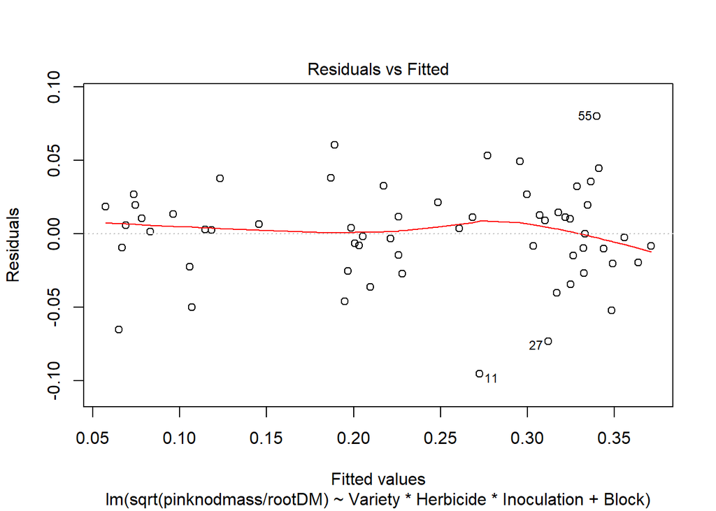

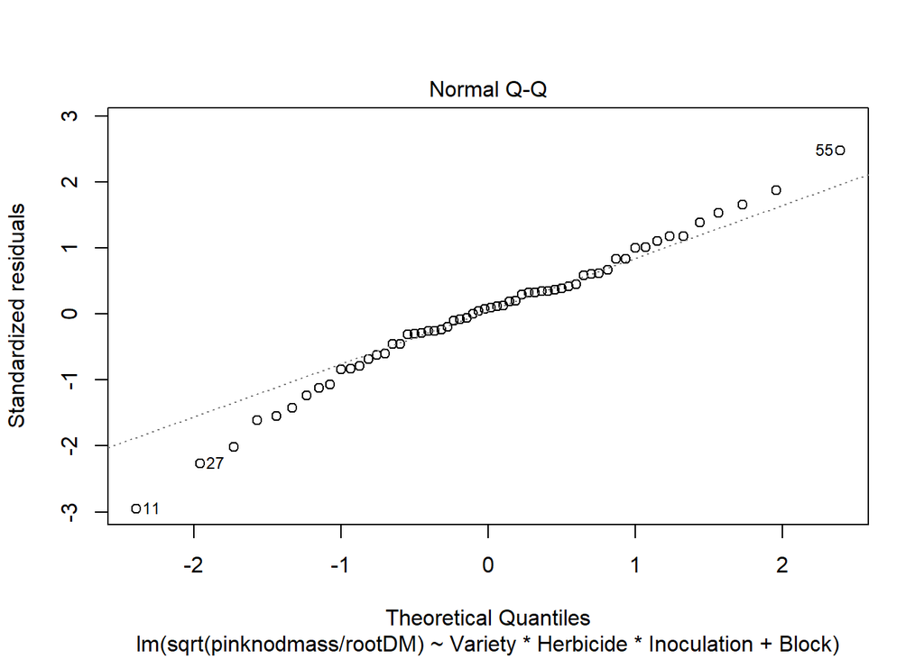

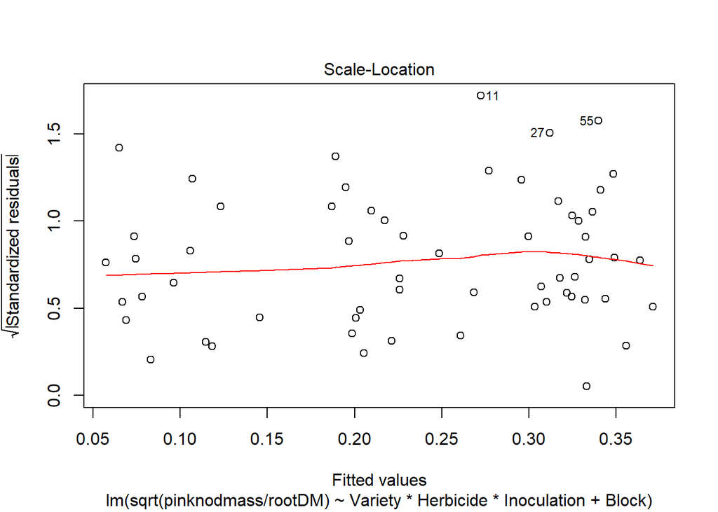

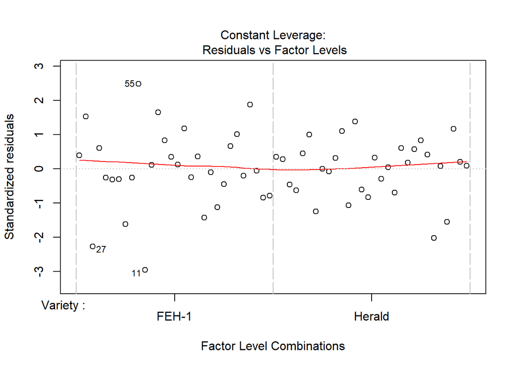

```r
plot(sqrtnodDMperrootDM_lm)
```

```r
emmeans(sqrtnodDMperrootDM_lm, ~ Variety*Herbicide, type="response")
```

```
##  Variety Herbicide      response          SE df    lower.CL   upper.CL
##  FEH-1   NoHerbicide 0.096730269 0.006058969 44 0.084904594 0.10932669
##  Herald  NoHerbicide 0.110269383 0.006469117 44 0.097617110 0.12369241
##  FEH-1   Herbicide   0.044173989 0.004094500 44 0.036307442 0.05281129
##  Herald  Herbicide   0.008452796 0.001791091 44 0.005228464 0.01244788
##
## Results are averaged over the levels of: Inoculation, Block
## Confidence level used: 0.95
## Intervals are back-transformed from the sqrt scale
```

```r
emmeans(sqrtnodDMperrootDM_lm, ~ Variety*Inoculation, type="response")
```

```
##  Variety Inoculation   response          SE df   lower.CL   upper.CL
##  FEH-1   RRI128      0.06563693 0.006112759 44 0.05389553 0.07853445
##  Herald  RRI128      0.04135295 0.004851951 44 0.03215255 0.05170948
##  FEH-1   washed      0.08166880 0.006818538 44 0.06850501 0.09598872
##  Herald  washed      0.04078698 0.004818634 44 0.03165373 0.05107637
##  FEH-1   herb        0.05750975 0.005721816 44 0.04655625 0.06961937
##  Herald  herb        0.05322204 0.005504386 44 0.04270674 0.06489346
##
## Results are averaged over the levels of: Herbicide, Block
## Confidence level used: 0.95
## Intervals are back-transformed from the sqrt scale
```

Again, there are some interesting interactions here that deserve some follow up. But the clear message is that nodule mass is more sensitive to herbicide than root mass, and it depends on the Variety.

### Uninoculated plants

We have focused on inoculated plants so far. Let’s take a closer look at the uninoculated plants which were included as controls.

```r
uninoculatedN_lm <- lm(shootN + bgN ~ Variety*Herbicide*Inoculation + Block, data=uninoculated)
anova(uninoculatedN_lm)
```

```
## Analysis of Variance Table
##
## Response: shootN + bgN
##                               Df  Sum Sq Mean Sq  F value    Pr(>F)
## Variety                        1    8.38    8.38   0.7526  0.393031
## Herbicide                      1  832.31  832.31  74.7725 2.149e-09 ***
## Inoculation                    1 1929.42 1929.42 173.3347 1.622e-13 ***
## Block                          4  174.64   43.66   3.9224  0.011887 *
## Variety:Herbicide              1   88.86   88.86   7.9828  0.008611 **
## Variety:Inoculation            1   11.41   11.41   1.0253  0.319937
## Herbicide:Inoculation          1  530.36  530.36  47.6464 1.675e-07 ***
## Variety:Herbicide:Inoculation  1    0.57    0.57   0.0509  0.823169
## Residuals                     28  311.67   11.13
## ---
## Signif. codes:  0 '***' 0.001 '**' 0.01 '*' 0.05 '.' 0.1 ' ' 1
```

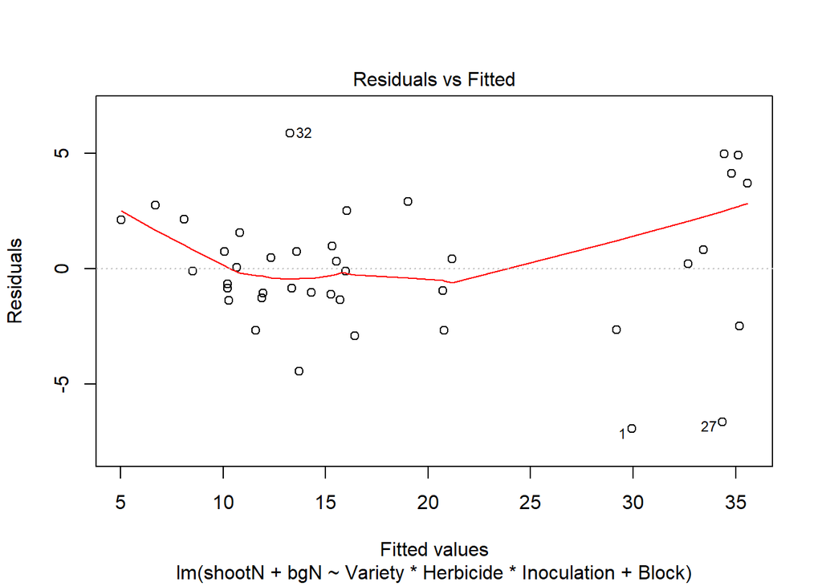

```r
plot(uninoculatedN_lm, which = 1)
```

```r
emmeans(uninoculatedN_lm, ~ Variety*Herbicide)
```

```
##  Variety Herbicide     emmean       SE df  lower.CL upper.CL
##  FEH-1   NoHerbicide 21.85838 1.055045 28 19.697221 24.01955
##  Herald  NoHerbicide 23.92402 1.055045 28 21.762858 26.08518
##  FEH-1   Herbicide   15.71620 1.055045 28 13.555038 17.87736
##  Herald  Herbicide   11.82002 1.055045 28  9.658854 13.98118
##
## Results are averaged over the levels of: Inoculation, Block
## Confidence level used: 0.95
```

```r
emmeans(uninoculatedN_lm, ~ Herbicide*Inoculation)
```

```
##  Herbicide   Inoculation   emmean       SE df  lower.CL upper.CL
##  NoHerbicide O-N         12.30472 1.055045 28 10.143557 14.46588
##  Herbicide   O-N         10.46422 1.055045 28  8.303057 12.62538
##  NoHerbicide O+N         33.47768 1.055045 28 31.316522 35.63885
##  Herbicide   O+N         17.07200 1.055045 28 14.910835 19.23316
##
## Results are averaged over the levels of: Variety, Block
## Confidence level used: 0.95
```

The residuals don’t look pretty, and that’s because the treatment combinations were so different from each other. If I subset the data and look only at the O+N treatment…

```r
plusN <- filter(allsamples, Inoculation %in% c("O+N"))

plusNN_lm <- lm(shootN + bgN ~ Variety*Herbicide + Block, data=plusN)
anova(plusNN_lm)
```

```
## Analysis of Variance Table
##
## Response: shootN + bgN
##                   Df  Sum Sq Mean Sq F value    Pr(>F)
## Variety            1   19.67   19.67  1.2163   0.29172
## Herbicide          1 1345.73 1345.73 83.1987 9.583e-07 ***
## Block              4  190.28   47.57  2.9410   0.06583 .
## Variety:Herbicide  1   37.62   37.62  2.3257   0.15317
## Residuals         12  194.10   16.17
## ---
## Signif. codes:  0 '***' 0.001 '**' 0.01 '*' 0.05 '.' 0.1 ' ' 1
```

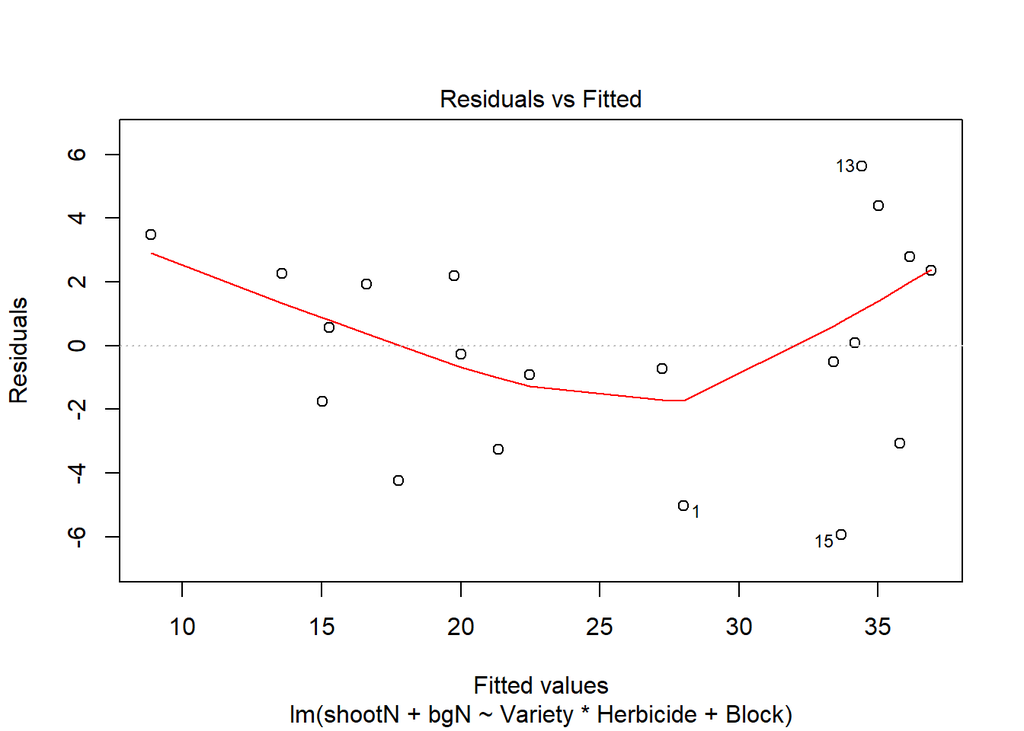

```r
plot(plusNN_lm, which = 1)
```

```r
emmeans(plusNN_lm, ~ Herbicide)
```

```
##  Herbicide     emmean       SE df lower.CL upper.CL
##  NoHerbicide 33.47768 1.271807 12 30.70666 36.24871
##  Herbicide   17.07200 1.271807 12 14.30097 19.84303
##
## Results are averaged over the levels of: Variety, Block
## Confidence level used: 0.95
```

There was a clear main effect of herbicide on plant N.

```r
uninoculatedDM_lm <- lm(shootDM + bgDM ~ Variety*Herbicide*Inoculation + Block, data=uninoculated)
anova(uninoculatedDM_lm)
```

```
## Analysis of Variance Table
##
## Response: shootDM + bgDM
##                               Df  Sum Sq Mean Sq  F value    Pr(>F)
## Variety                        1 0.01212 0.01212   1.5081 0.2296587
## Herbicide                      1 1.08491 1.08491 135.0222 3.171e-12 ***
## Inoculation                    1 0.12488 0.12488  15.5420 0.0004904 ***
## Block                          4 0.16324 0.04081   5.0789 0.0033189 **
## Variety:Herbicide              1 0.14675 0.14675  18.2636 0.0002010 ***
## Variety:Inoculation            1 0.00476 0.00476   0.5920 0.4480891
## Herbicide:Inoculation          1 0.14607 0.14607  18.1792 0.0002064 ***
## Variety:Herbicide:Inoculation  1 0.01105 0.01105   1.3751 0.2508187
## Residuals                     28 0.22498 0.00804
## ---
## Signif. codes:  0 '***' 0.001 '**' 0.01 '*' 0.05 '.' 0.1 ' ' 1
```

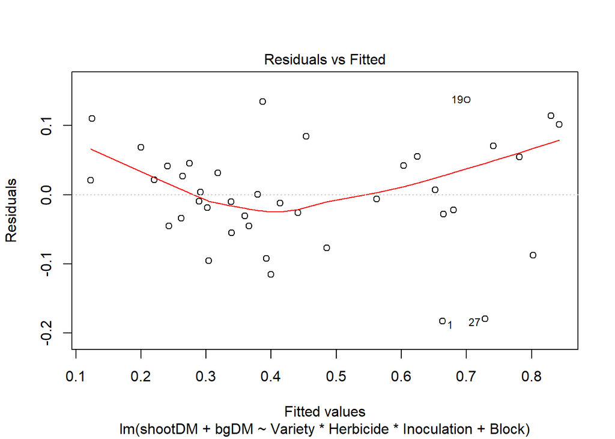

```r
plot(uninoculatedDM_lm, which = 1)
```

```r
emmeans(uninoculatedDM_lm, ~ Variety*Herbicide)
```

```
##  Variety Herbicide    emmean         SE df  lower.CL  upper.CL
##  FEH-1   NoHerbicide 0.53893 0.02834619 28 0.4808655 0.5969945
##  Herald  NoHerbicide 0.69488 0.02834619 28 0.6368155 0.7529445
##  FEH-1   Herbicide   0.33069 0.02834619 28 0.2726255 0.3887545
##  Herald  Herbicide   0.24436 0.02834619 28 0.1862955 0.3024245
##
## Results are averaged over the levels of: Inoculation, Block
## Confidence level used: 0.95
```

```r
emmeans(uninoculatedDM_lm, ~ Herbicide*Inoculation)
```

```
##  Herbicide   Inoculation  emmean         SE df  lower.CL  upper.CL
##  NoHerbicide O-N         0.50060 0.02834619 28 0.4425355 0.5586645
##  Herbicide   O-N         0.29208 0.02834619 28 0.2340155 0.3501445
##  NoHerbicide O+N         0.73321 0.02834619 28 0.6751455 0.7912745
##  Herbicide   O+N         0.28297 0.02834619 28 0.2249055 0.3410345
##
## Results are averaged over the levels of: Variety, Block
## Confidence level used: 0.95
```

Could do with a transformation here, but the results are quite clear. The biomass response is a bit different from the N response. For O-N plants, the nitrogen content didn’t really drop with herbicide application. However dry matter did decline, due in part to timing of application and continued growth until harvest in plants without herbicide accompanied by a decline in N concentration.

## Bringing it all together

Overall, the statistical modelling support the stories we discovered during the visualisation. In addition the statistical modelling also revealed some subtleties that we overlooked.

The key points are that:

- FEH-1 is not fully tolerant to group B herbicides. However in the presence of herbicide, FEH-1 can continue to grown and fix nitrogen whereas Herald was knocked out.
- Symbiotic nitrogen fixation is not as optimal in FEH-1 as in Herald in the absence of herbicide, which is also reflected in growth.
- It appears that there are similar treatment effects of Variety and Herbicide on nitrogen contents and biomass, but there is some plasticity there.
- Shoots were affected differently to roots, which may be due to the topical application of herbicide to the shoots in this experiment.
- Despite the application of herbicide to the shoots, nodule mass was more sensitive to herbicide than root mass. This may simply be a matter of timing of herbicide application.
- There were some interactions involving rhizobia treatments indicating potential carryover of herbicide from cultures of rhizobia and also the potential importance of topical exposure to herbicide.
- This experiment was a an attempt to use a herbicide tolerant host to identify potential mechanisms by which group B herbicides affect nitrogen fixation. It was a good first look and much was learnt about the experimental system. However some well designed experiments are needed to better represent real agricultural systems, and also to get a better mechanistic understanding of how group B herbicides affect nodulation and nitrogen fixation.

## What did I learn?

### Approach to experiments and analysis

This experiment was done more than 10 years ago. It was interesting to compare my approach this time to my approach back then. I deliberately started from scratch, cutting the data right back to the raw data. In going through the exploration and analysis I had to reacquaint myself with the questions I originally set out to answer. This made it really obvious that experimental design should be done to answer specific questions, then the statistical modelling flows very easily from the experimental design.

### Visualisation

Visualisation is super useful both for data exploration and data explanation. In the past I had taken the raw data, done a heap of calculations then run through lots of statistics looking for differences. This can soon turn into a big muddle. Now my approach is to focus on the questions, design the experiments, use visualisations to explore the data, look for stories, then run the statistical models to test those stories and look for things I may have missed. Finally, and I haven’t gotten to this yet, work on visualisations to effectively communicate what the data is telling you to your audience.

### Statistical modelling

Make the statistical modelling work for you. It should flow naturally from the experimental design, which should flow naturally from the questions you set out to answer. Think about statistical modelling from the perspective of supporting your data to answer the questions you are interested in, rather than it being an exercise to get an arbitrary p value just so you can a paper past some reviewer who doesn’t really understand p values.

### Workflows and documentation

Using Rmarkdown is an excellent way to organise, conduct and document your work. It enables you to bring together the data, the exploratory visualisation, the statistical modelling, the explanatory visualisation and the reporting into a single document that is easily to update with version control, easy to use for presenting and discussing, and gives you the ability to make into a nice shiny document as an html or pdf, all in the one place. Brilliant.

No doubt markdown has a lot of functionality that I still need to explore, such as pandoc formatting for the final document. But even before that, you have the ability to show or hide chunks or sections, keep all the code and choose whether or not it, warning messages or results appear in the final document.

### Next steps

A large part of my future work will be in chemometrics using multivariate analysis, principal components analysis, partial least squares regression, piece-wise direct standardisation.

I would like to get more proficient at r markdown, to the point where I can use it to produce publication quality reports and manuscripts for submission.

I would also like to improve my ggplot skills, and think more about how to use visualisation for explanation and publication, not just exploration. To do so, I need to improve on manipulating data using Tidyverse - I still don’t fully understand gathers and things.

I will also be doing more modelling work so sampling data from distributions and outputting model outcomes probabalistically and generating explanatory visualisations would be very useful. The approaches would be similar to what people do for sensitivity and uncertainty analyses. I’m not sure how related these are to statistical methods.

### Questions

- Subsetting data
- Specifying which contrasts you want
- What people ended up plotting for reporting purposes - when the visualisations already tell a good story, what do you add? ablines, confidence intervals..